# Análise Exploratória

Base Plot

Delermando Branquinho Filho

## Plotting System

O núcleo plotting e motor gráfico em R é encapsulado no Seguintes pacotes:

- - gráficos *: contém funções de traçado para a representação gráfica “base” Sistemas, incluindo ‘parcela’, `hist`,`boxplot` e muitos outros.
- - grDevices *: contém todo o código que implementa os vários gráficos Dispositivos, incluindo X11, PDF, PostScript, PNG, etc.

O sistema de trama de rede é implementado usando as seguintes embalagens:

- - lattice *: contém código para produzir gráficos Trellis, que são Independente do sistema gráfico “base”; Inclui funções como `Xyplot`,`bwplot`, `levelplot`
- - grid *: implementa um sistema gráfico diferente, independente do Sistema “base”; O pacote* lattice * é construído em cima de * grid *; nós Raramente chamar funções do pacote* grid * diretamente

## O processo de fazer uma plotagem

Ao fazer uma trama, deve-se primeiro fazer algumas considerações (não Necessariamente nesta ordem):

- Onde o plano será feito? Na tela? Em um arquivo?

- Como será usada a trama?
- É a trama para visualização temporária na tela?
- Será apresentado em um navegador web?
- Será que eventualmente acabar em um papel que pode ser impresso?
- Você está usando isso em uma apresentação?
- Há uma grande quantidade de dados entrando na trama? Ou é apenas um Poucos pontos
- Você precisa ser capaz de redimensionar dinamicamente o gráfico?

## O processo de fazer uma plotagem

- Que sistema gráfico você vai usar: base, lattice ou ggplot2? Estes Geralmente não podem ser misturado.
- Os gráficos de base são geralmente construídos de forma fragmentada, com cada O enredo tratado separadamente através de uma série de chamadas de função; esta É muitas vezes conceitualmente mais simples e permite traçar um espelho processo de pensamento
- Gráficos Lattice são normalmente criados em uma única chamada de função, por isso Todos os parâmetros gráficos devem ser especificados de uma vez; Especificando Tudo ao mesmo tempo permite R calcular automaticamente o necessário Espaçamentos e tamanhos de fonte.
- ggplot2 combina conceitos de gráficos de base e de retículo, mas Utiliza uma implementação independente

Nós nos concentramos em usar o ** sistema de plotagem base ** para criar gráficos em O ** dispositivo de tela **.

## Base Gráficos

Gráficos de base são usados mais comumente e são um sistema muito poderoso para criar gráficos em 2-D.

- Existem duas * fases * para a criação de um plano de base
- Inicializando uma nova trama
- Anotar (adicionar) uma parcela existente
- Chamando `parcela (x, y)` ou `hist (x)` irá lançar um dispositivo gráfico (se Um já não está aberto) e desenhar um novo enredo no dispositivo
- Se os argumentos para `plot` não forem de alguma classe especial, *default* método para `plot` é chamado; Esta função tem *many* Argumentos, permitindo definir o título, rótulo do eixo x, rótulo do eixo y, Etc
- O sistema gráfico base tem _muitos parâmetros que podem definir e Tweaked; Esses parâmetros estão documentados em `? Par`; Não faria mal Para tentar memorizar esta página de ajuda!

## Simple Base Graphics: Histogram

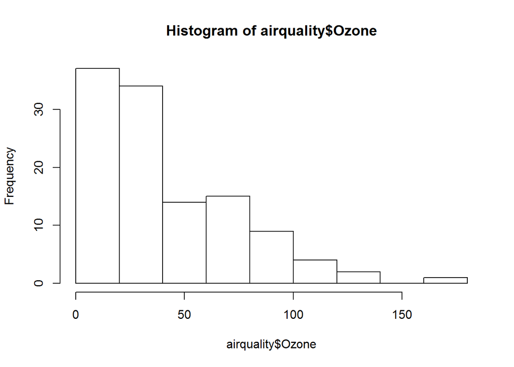

```r
library(datasets)
hist(airquality$Ozone)  ## Draw a new plot
```

## Simple Base Graphics: Scatterplot

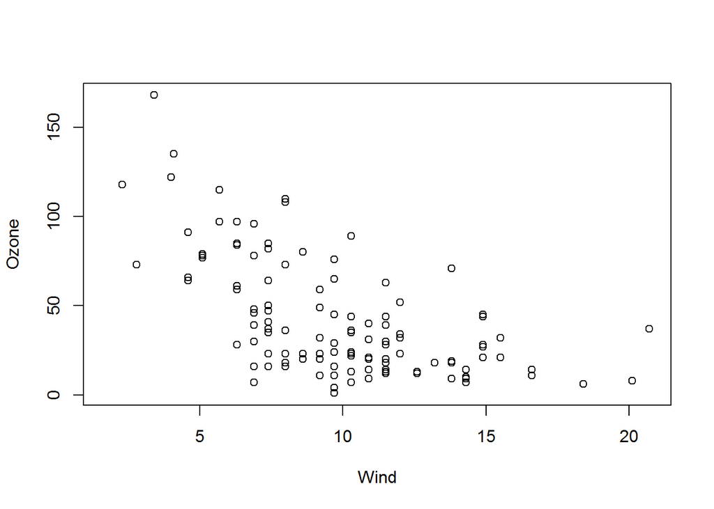

```r
library(datasets)
with(airquality, plot(Wind, Ozone))
```

## Simple Base Graphics: Boxplot

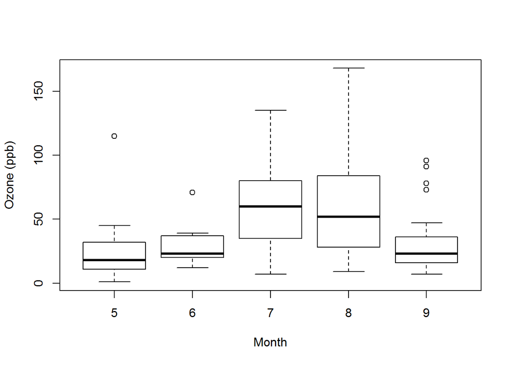

```r
library(datasets)
airquality <- transform(airquality, Month = factor(Month))
boxplot(Ozone ~ Month, airquality, xlab = "Month", ylab = "Ozone (ppb)")
```

## Alguns Parâmetros Gráficos de Base Importantes

Muitas funções básicas de plotagem compartilham um conjunto de parâmetros. Aqui estão alguns Chave:

- `pch`: o símbolo de plotagem (o padrão é círculo aberto)
- `lty`: o tipo de linha (padrão é a linha contínua), pode ser tracejado, pontilhado, etc.
- `lwd`: a largura da linha, especificada como um múltiplo inteiro
- `col`: a cor de plotagem, especificada como um número, string ou código hex;
- A função `colors ()` dá-lhe um vector de cores por nome
- `xlab`: cadeia de caracteres para a etiqueta do eixo x
- `ylab`: cadeia de caracteres para o rótulo do eixo y

## Alguns Parâmetros Gráficos de Base Importantes

A função `par ()` é usada para especificar * global * graphics parameters Que afetam todas as parcelas em uma sessão R. Esses parâmetros podem ser Substituídos quando especificados como argumentos para funções de traçado específicas.

- `las`: a orientação dos rótulos do eixo na trama
- `bg`: a cor de fundo
- «mar»: o tamanho da margem
- `oma`: o tamanho da margem externa (o padrão é 0 para todos os lados)
- `mfrow`: número de parcelas por linha, coluna (as parcelas são preenchidas em linha)

## Some Important Base Graphics Parameters

Default values for global graphics parameters

```r
par("lty")
```

```
## [1] "solid"
```

```r
par("col")
```

```
## [1] "black"
```

```r
par("pch")
```

```
## [1] 1
```

## Alguns Parâmetros Gráficos de Base Importantes

Valores padrão para parâmetros gráficos globais

```r
par("bg")
```

```
## [1] "white"
```

```r
par("mar")
```

```
## [1] 5.1 4.1 4.1 2.1
```

```r
par("mfrow")
```

```
## [1] 1 1
```

## Base Plot com anotação

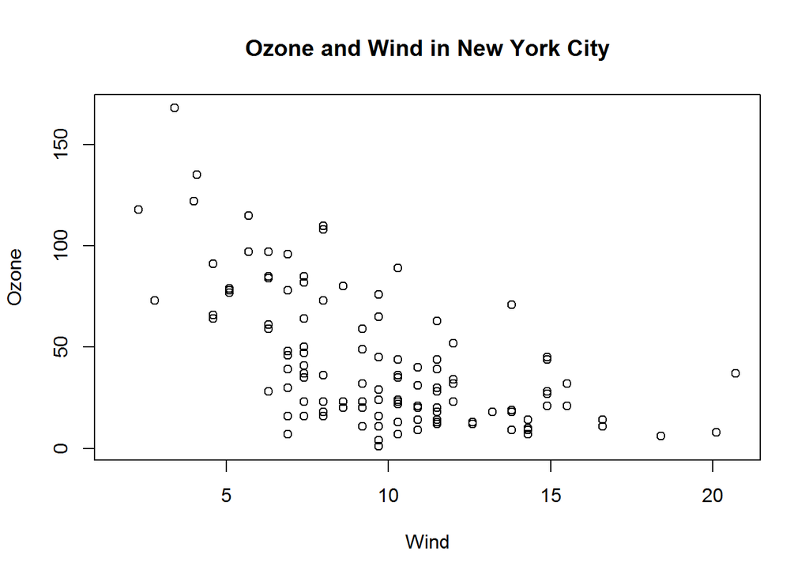

```r
library(datasets)
with(airquality, plot(Wind, Ozone))
title(main = "Ozone and Wind in New York City")  ## Add a title
```

## Base Plot com anotação

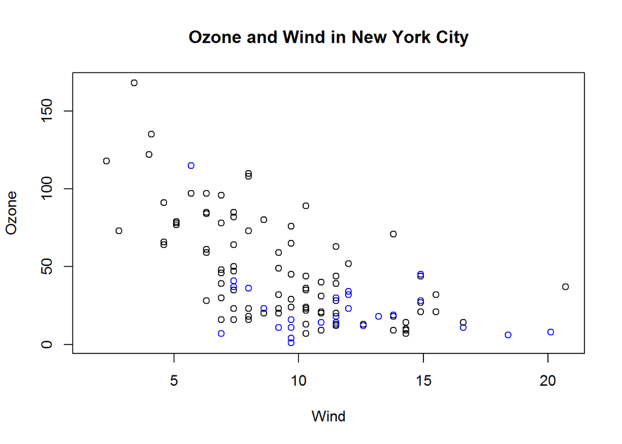

```r
with(airquality, plot(Wind, Ozone, main = "Ozone and Wind in New York City"))
with(subset(airquality, Month == 5), points(Wind, Ozone, col = "blue"))
```

## Base Plot com anotação

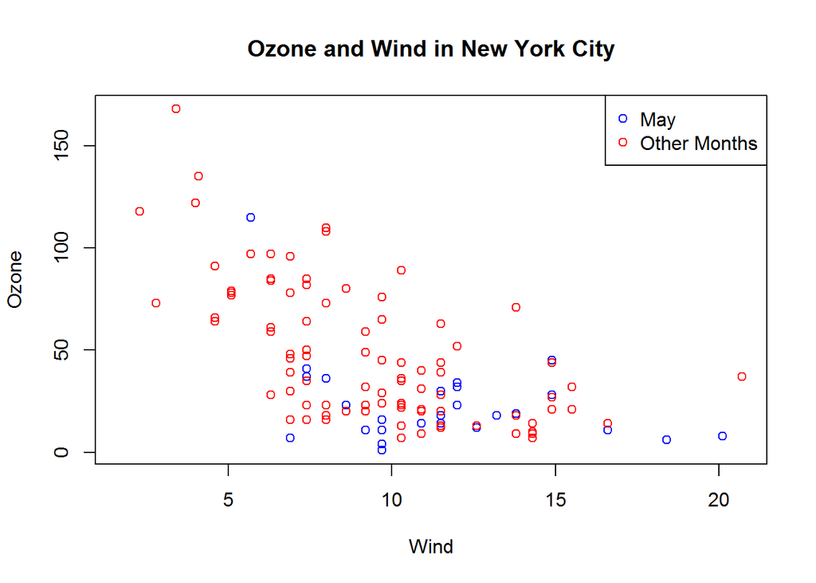

```r
with(airquality, plot(Wind, Ozone, main = "Ozone and Wind in New York City", type = "n"))
with(subset(airquality, Month == 5), points(Wind, Ozone, col = "blue"))
with(subset(airquality, Month != 5), points(Wind, Ozone, col = "red"))
legend("topright", pch = 1, col = c("blue", "red"), legend = c("May", "Other Months"))
```

## Base Plot com linha de Regressão

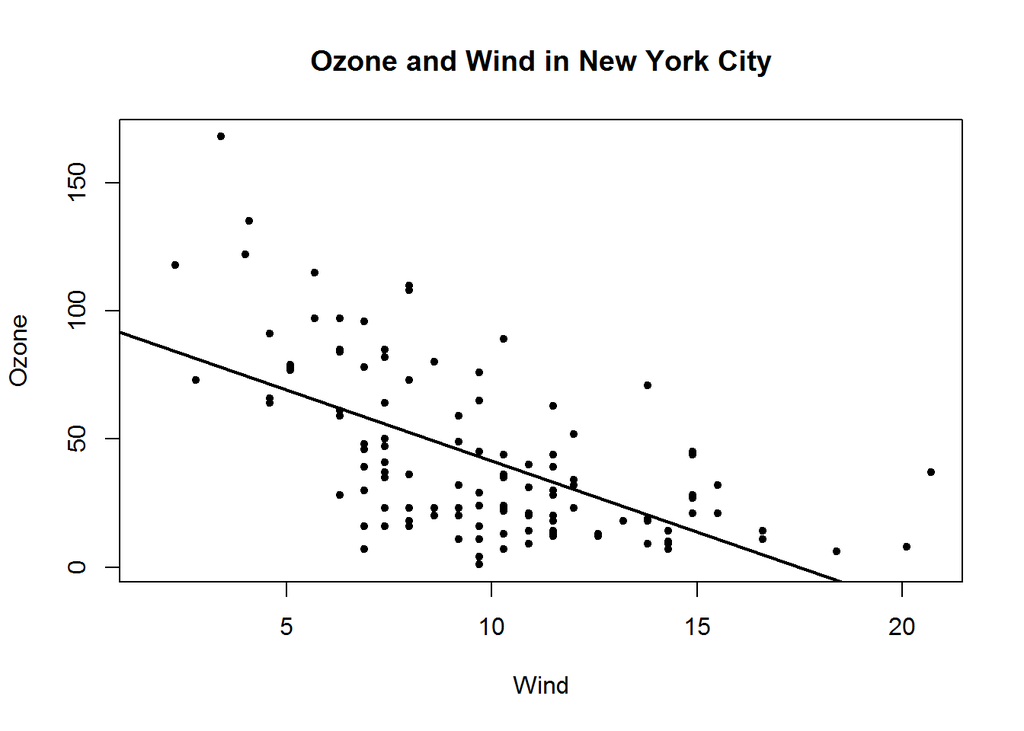

```r
with(airquality, plot(Wind, Ozone, main = "Ozone and Wind in New York City", pch = 20))
model <- lm(Ozone ~ Wind, airquality)
abline(model, lwd = 2)
```

## Multiple Base Plots

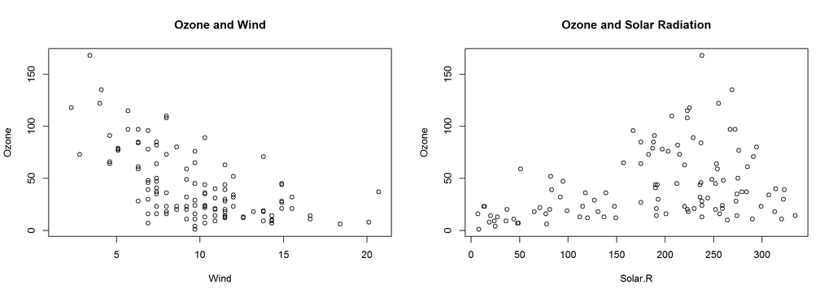

```r
par(mfrow = c(1, 2))
with(airquality, {
    plot(Wind, Ozone, main = "Ozone and Wind")
    plot(Solar.R, Ozone, main = "Ozone and Solar Radiation")
})
```

## Multiple Base Plots

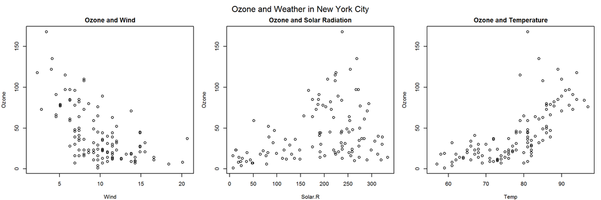

```r
par(mfrow = c(1, 3), mar = c(4, 4, 2, 1), oma = c(0, 0, 2, 0))
with(airquality, {
    plot(Wind, Ozone, main = "Ozone and Wind")
    plot(Solar.R, Ozone, main = "Ozone and Solar Radiation")
    plot(Temp, Ozone, main = "Ozone and Temperature")
    mtext("Ozone and Weather in New York City", outer = TRUE)
})
```